# Stroop Task - Statistics

```python
import numpy as np
import pandas as pd
```

Import numpy and pandas to analyzethe dataset.

```python
stroop = pd.read_csv('stroopdata.csv')
```

This dataset contains results from a number of participants in the task. Each row of the dataset contains the performance for one participant, with the first number their results on the congruent task and the second number their performance on the incongruent task.

1. The independent variable is the two tasks (congruent and incongruent), and the dependent variable is the time it takes to name the ink colors.
2. Hypothesis Test: I would like to test if the performance on the congruent task is significantly different from the performance on the incongruent task for any people (not just the sample). To do that, I will use T-test to justify it. The reason why I use T-test is because we have less than 30 samples and we don't know the population's standard deviation. We also assume that the distribution is normal distribution.

uC - congruent population mean. uL - incongruent population mean.

Null hypothese: uC = uL (the population mean of the time to name the incongruent words is the same as the population mean of the time to name the congruent words.) Alternative hypothese: uC<uL (the population mean of the time to name the congruent words is less than the population mean of the time to name the congruent words.)

```python
stroop.describe()
```

|  | Congruent | Incongruent |
| --- | --- | --- |
| count | 24.000000 | 24.000000 |
| mean | 14.051125 | 22.015917 |
| std | 3.559358 | 4.797057 |
| min | 8.630000 | 15.687000 |
| 25% | 11.895250 | 18.716750 |
| 50% | 14.356500 | 21.017500 |
| 75% | 16.200750 | 24.051500 |
| max | 22.328000 | 35.255000 |

```python
stroop.median()
```

```
Congruent      14.3565
Incongruent    21.0175
dtype: float64
```

There are 24 records in the dataset. The mean and median of congruent task are 14.05 and 14.35 while the mean and median of incongruent task is 22.01 and 21.01. The standard deviation of congruent task is 3.56 and std of incongruent task is 4.79.

```
array([[<matplotlib.axes._subplots.AxesSubplot object at 0x000000000BE201D0>,
        <matplotlib.axes._subplots.AxesSubplot object at 0x000000000BFDCF60>]], dtype=object)
```

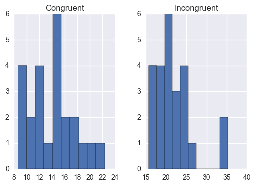

```python
import matplotlib.pyplot as plt
import seaborn as sns
%matplotlib inline
stroop.hist()
```

```python
from scipy import stats
```

I'm going to use T-test for the paired test (related data).

```python
stats.ttest_rel(stroop['Congruent'],stroop['Incongruent'])
```

```
Ttest_relResult(statistic=-8.020706944109957, pvalue=4.1030005857111781e-08)
```

The T-statistics is -8.02 and p-value is smaller than 0.001. Since my confidence level is 99%, the critical value should be -2.5 (for one-tailed dependent t-test). So I will reject the null hypothese which is assuming the performance of congruent and incongruent task is identical. In this case, my conclusion is that the performance of congruent and incongruent task is significantly different, which is expected.

Optional question: My guess of this kind of result is because the color and word create the conflict to our brain, so it processes slower than it normally does. Another example might be give a direction of right and put "left" word on top of it. It might result in smiliar effect.